# A4 Tasks

Karri Miettinen

2024-09-26

# A4_T1 For-loop 1

Create a Python program which prompts user to insert two integers. Use these integers together with the “for-loop” structure to create behaviour like in the example program example run below.

Note! the autograding tool will test that the correct structure has been applied.

**Example program runs**

```
Program starting.

Insert starting value: 1
Insert stopping value: 10

Starting for-loop:
1
2
3
4
5
6
7
8
9
10

Program ending.
```

```
Program starting.

Insert starting value: 2
Insert stopping value: 7

Starting for-loop:
2
3
4
5
6
7

Program ending.
```

```
Program starting.

Insert starting value: 11
Insert stopping value: 13

Starting for-loop:
11
12
13

Program ending.
```

# A4_T2 For-loop 2

Copy the previous program and modify the behaviour to match the example program run below. This program must use “for-loop” structure.

It is recommended to replace the print-command end character with space, so that all the iterations can be printed on the same row. Last iteration might require additional logic to get rid of the extra space at the end.

Note! the autograding tool will test that the correct structure has been applied.

**Example program runs**

```
Program starting.

Insert starting value: 1
Insert stopping value: 10

Starting for-loop:
1 2 3 4 5 6 7 8 9 10

Program ending.
```

```
Program starting.

Insert starting value: 2
Insert stopping value: 7

Starting for-loop:
2 3 4 5 6 7

Program ending.
```

```
Program starting.

Insert starting value: 11
Insert stopping value: 15

Starting for-loop:
11 12 13 14 15

Program ending.
```

# A4_T3 While-loop

Make Python program which prompts user to insert two integers. Use these integers together with the “while-loop” structure to create behaviour like in the example program run below.

Note! the autograding tool will test that the correct structure has been applied.

**Example program runs**

```
Program starting.

Insert starting value: 1
Insert stopping value: 10

Starting while-loop:
1 2 3 4 5 6 7 8 9 10

Program ending.
```

```
Program starting.

Insert starting value: 2
Insert stopping value: 8

Starting while-loop:
2 3 4 5 6 7 8

Program ending.
```

```
Program starting.

Insert starting value: 3
Insert stopping value: 14

Starting while-loop:
3 4 5 6 7 8 9 10 11 12 13 14

Program ending.
```

# A4_T4 Repetitive prompt

Make a program, which prompts user to insert words. Program must stop prompting words if user inserts empty word. After stopping the repetitive prompt, print the amount of words and characters that the user inserted.

**Example program run:**

```
Program starting.

Insert word (empty stops): Close
Insert word (empty stops): the
Insert word (empty stops): loop
Insert word (empty stops):

You inserted:
- 3 words
- 12 characters

Program ending.
```

```
Program starting.

Insert word (empty stops): Five
Insert word (empty stops): Four
Insert word (empty stops): Three
Insert word (empty stops): Two
Insert word (empty stops): One
Insert word (empty stops):

You inserted:
- 5 words
- 19 characters

Program ending.
```

```
Program starting.

Insert word (empty stops): Eenie
Insert word (empty stops): meenie
Insert word (empty stops): miney
Insert word (empty stops): mo
Insert word (empty stops): Catch
Insert word (empty stops): a
Insert word (empty stops): tiger
Insert word (empty stops): by
Insert word (empty stops): the
Insert word (empty stops): toe
Insert word (empty stops):

You inserted:
- 10 words
- 37 characters

Program ending.
```

# A4_T5 Break and continue

Make a program, which prompts user to insert three integers:

1. Starting point
2. Stopping point
3. Inspection point

Test the points with following rules(Note! testing order matters):

1. Starting point must be less than stopping point
   - `"Starting point value must be less than the stopping point value."`
2. The inspection point must be within the range of the start and stop points.
   - `"Inspection value must be within the range of start and stop."`

If any rule above is broken, print the violation message(s) to the user and then skip the next part till the `"Program ending."` print.

Run two for-loops like shown in the example program runs if none of the rules above are broken. Inside the loops, compare the inspection point to the current iteration. Use `break` and `continue` commands if the current iteration is same as the inspection point. Otherwise print the current iteration on the same line.

Note! There must be no trailing space character at the end of any row.

**Example program runs**

```
Program starting.

Insert starting point: 3
Insert stopping point: 8
Insert inspection point: 5

First loop - inspection with break:
3 4
Second loop - inspection with continue:
3 4 6 7

Program ending.
```

```
Program starting.

Insert starting point: 3
Insert stopping point: 8
Insert inspection point: 2

Inspection value must be within the range of start and stop.

Program ending.
```

```
Program starting.

Insert starting point: 3
Insert stopping point: 3
Insert inspection point: 8

Starting point value must be less than the stopping point value.
Inspection value must be within the range of start and stop.

Program ending.
```

```
Program starting.

Insert starting point: 3
Insert stopping point: 8
Insert inspection point: 3

First loop - inspection with break:

Second loop - inspection with continue:
4 5 6 7

Program ending.
```

```
Program starting.

Insert starting point: 3
Insert stopping point: 8
Insert inspection point: 8

First loop - inspection with break:
3 4 5 6 7
Second loop - inspection with continue:
3 4 5 6 7

Program ending.
```

```
Program starting.

Insert starting point: 5
Insert stopping point: 18
Insert inspection point: 10

First loop - inspection with break:
5 6 7 8 9
Second loop - inspection with continue:
5 6 7 8 9 11 12 13 14 15 16 17

Program ending.
```

# A4_T6 Collatz Conjecture (TEST TASK)

This mathematical problem is described in the following video: youtu.be/094y1Z2wpJg

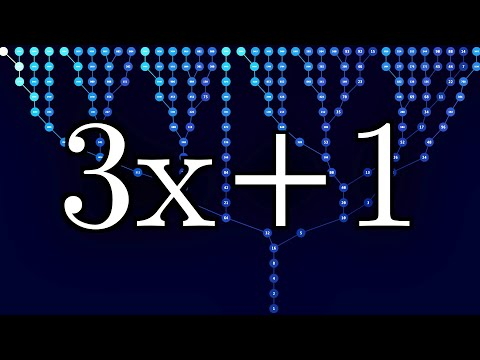

Click to play in YouTube

Also at the wikipedia: en.wikipedia.org/wiki/Collatz_conjecture

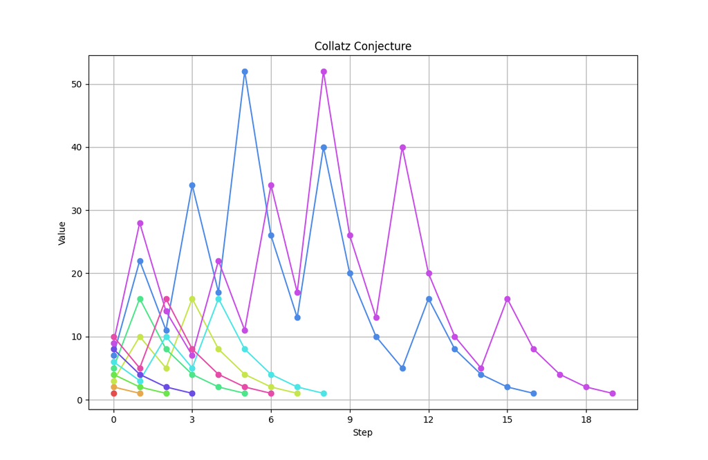

Collatz Conjecture 1 - 10

Create a program which prompts the user to insert an integer and then display the collatz conjecture as shown in the examples below.

```
Program starting.
Insert a positive integer: 10
10 -> 5 -> 16 -> 8 -> 4 -> 2 -> 1
Sequence had 6 total steps.

Program ending.
```

```
Program starting.
Insert a positive integer: 6
6 -> 3 -> 10 -> 5 -> 16 -> 8 -> 4 -> 2 -> 1
Sequence had 8 total steps.

Program ending.
```

```
Program starting.
Insert a positive integer: 7
7 -> 22 -> 11 -> 34 -> 17 -> 52 -> 26 -> 13 -> 40 -> 20 -> 10 -> 5 -> 16 -> 8 -> 4 -> 2 -> 1
Sequence had 16 total steps.

Program ending.
```

```
Program starting.
Insert a positive integer: 27
27 -> 82 -> 41 -> 124 -> 62 -> 31 -> 94 -> 47 -> 142 -> 71 -> 214 -> 107 -> 322 -> 161 -> 484 -> 242 -> 121 -> 364 -> 182 -> 91 -> 274 -> 137 -> 412 -> 206 -> 103 -> 310 -> 155 -> 466 -> 233 -> 700 -> 350 -> 175 -> 526 -> 263 -> 790 -> 395 -> 1186 -> 593 -> 1780 -> 890 -> 445 -> 1336 -> 668 -> 334 -> 167 -> 502 -> 251 -> 754 -> 377 -> 1132 -> 566 -> 283 -> 850 -> 425 -> 1276 -> 638 -> 319 -> 958 -> 479 -> 1438 -> 719 -> 2158 -> 1079 -> 3238 -> 1619 -> 4858 -> 2429 -> 7288 -> 3644 -> 1822 -> 911 -> 2734 -> 1367 -> 4102 -> 2051 -> 6154 -> 3077 -> 9232 -> 4616 -> 2308 -> 1154 -> 577 -> 1732 -> 866 -> 433 -> 1300 -> 650 -> 325 -> 976 -> 488 -> 244 -> 122 -> 61 -> 184 -> 92 -> 46 -> 23 -> 70 -> 35 -> 106 -> 53 -> 160 -> 80 -> 40 -> 20 -> 10 -> 5 -> 16 -> 8 -> 4 -> 2 -> 1
Sequence had 111 total steps.

Program ending.
```

# A4_T7 Multiplicative persistency (TEST TASK)

This mathematical problem is described in the following video: youtu.be/Wim9WJeDTHQ

[figure not shown]

Click to play in YouTube

Also at the wikipedia: en.wikipedia.org/wiki/Persistence_of_a_number

Create program which prompts the user to insert an integer and then display the steps to calculate the multiplicative persistency based on the user input.

In short, the steps in the multiplicative persistency is calculated by multiplying digits together in a given integer. This process is then repeated for the result which makes the result value smaller on each iteration till the result contains only one digit.

The program must stop the iteration when the result contains only one digit. Finally before the program closes, it shows the steps taken.

**Example program runs**

```
Program starting.

Check multiplicative persistence.
Insert an integer: 277777788888899
2 * 7 * 7 * 7 * 7 * 7 * 7 * 8 * 8 * 8 * 8 * 8 * 8 * 9 * 9 = 4996238671872
4 * 9 * 9 * 6 * 2 * 3 * 8 * 6 * 7 * 1 * 8 * 7 * 2 = 438939648
4 * 3 * 8 * 9 * 3 * 9 * 6 * 4 * 8 = 4478976
4 * 4 * 7 * 8 * 9 * 7 * 6 = 338688
3 * 3 * 8 * 6 * 8 * 8 = 27648
2 * 7 * 6 * 4 * 8 = 2688
2 * 6 * 8 * 8 = 768
7 * 6 * 8 = 336
3 * 3 * 6 = 54
5 * 4 = 20
2 * 0 = 0
No more steps.

This program took 11 step(s)

Program ending.
```

```
Program starting.

Check multiplicative persistence.
Insert an integer: 796
7 * 9 * 6 = 378
3 * 7 * 8 = 168
1 * 6 * 8 = 48
4 * 8 = 32
3 * 2 = 6
No more steps.

This program took 5 step(s)

Program ending.
```

```
Program starting.

Check multiplicative persistence.
Insert an integer: 10000000000
1 * 0 * 0 * 0 * 0 * 0 * 0 * 0 * 0 * 0 * 0 = 0
No more steps.

This program took 1 step(s)

Program ending.
```

```
Program starting.

Check multiplicative persistence.
Insert an integer: 7
No more steps.

This program took 0 step(s)

Program ending.
```